# A3: Incarceration

Kaiyun Zheng

2023-08-05

### Introduction

All men are created equal, a quotation that has been celebrated and circulated, yet not been implemented in United State these years. In fact, racism is still prevalent in the United States. A complex set of social and political structures prevents people from being treated fairly, and this racism is most evident in its criminal legal system. A system of over-criminalization of people of color has resulted in disproportionate incarceration of people of color. Additionally, there is a high degree of stereotypical bias in the police’s use of unfair means and force against colored people. All of these ultimately lead to the existence of racial disparities in incarceration.

Based on this, this data visualization project will focus on two data sets: Dataset about Jail population per county/state and Dataset about Prison population per county/state. It is going to look through the situation in the United States as a whole, to get a general idea of the situation in this country. The analysis will look specifically at trends in each ethnic group’s share of jail time; to explore whether there is a correlation between the jail and prison populations, and to compare the specific conditions of blacks and whites on this basis; and recent incarceration rates by states around U.S..

I hope this study builds enough awareness to make people realize that the inequities and racism of incarceration are real.

### Summary Information

The summary script confirms essential information from the complete analysis. It reveals that the lowest black jail rate occurred in 2018, at 0.86%, while the highest rate was observed in 2006, at 1.15%. The data demonstrates a consistent decline in the black jail rate over the years, hinting at a potentially positive future trend.

In 2016, a correlation between jail population and prison population was observed for both black and white individuals. However, the ratio for black individuals was notably higher, standing at 2.47. This suggests that for every 100 black people in jail, approximately 247 black people are in prison, compared to the white ratio of 1.44, where 100 white people in jail correspond to approximately 144 white people in prison. These findings raise concerns about the existence of discrimination against black individuals in the sentencing and imprisonment process within the United States.

Moreover, the data from 2016 reveals significant disparities between states. Louisiana had the highest jail rate, at 0.622%, while Connecticut, Delaware, Hawaii, Rhode Island, and Vermont had the lowest jail rates, with no individuals in jail at all. These variations between states point to potential differences in law enforcement, justice systems, or other societal factors that warrant further investigation.

### The Dataset

The dataset about jail population per county/state and the dataset about prison population per county/state used in the analysis is collected by Vera Institude of Justice. The data was employed two Bureau of Justice Statistics (BJS) data collections: the Census of Jails (COJ) and the Annual Survey of Jails (ASJ). This data is collected due to the final goal of the Vera Institute of Justice, building and creating justice systems that ensure fairness, promote safety, and strengthen communities. To be more specific, the data is prepare for exposing the potentially existed racist, unjust, and unequal incarceration.

The data set about jail population has 153811 observations and 28 features. The data set about prison population has 153811 observations and 36 features. As two large data sets, they need to be processed more carefully.

Although the dataset is generated from the Institude of Justice which is authoritative, it still needs to consider the ethical questions and questions of power when working with this data. From ethical level, these data may not be provided by individuals voluntarily, and may contain private and personal information. Even, people may not know that the data is published and available to the general public, which makes using these data sets need more consideration of ethical issues. Another important aspect to bear in mind is the potential for deeper stereotyping based on demographics such as race or gender. The mere presence of a higher number of individuals from a specific ethnic group in jails does not imply the entire group should be associated with criminality or that they are inherently “bad” people. It is crucial to approach data analysis with caution, considering the broader context to detect and rectify any instances of unfair incarceration. Although these data are provided by a government agency, an authoritative body, it does not mean that the data are absolutely objective. They may still have hidden and concealed parts, modified or unpublished, in order to protect the interests of specific groups of people. In this case, question of power might still occur and affect data results, allowing unjust incarceration to be concealed.

The data have some possible limitations and problems which needs attention. First, data discontinuity may occur due to the methodology for collecting the overall population of jails and the population of specific races in them is different, there may be differences or missing data during the period. In this Jail population data set, it misses most of details value before 1990 due to missing collections. In this analysis, the data before 1985 has not been considered and analyzed because of this background. Additionally, this data only considers variables such as the number of people, the size of the population, and the size of the prison, and does not involve too much background information. The different policies of each state in the United States should also be considered. Whether there is preferential treatment for various races in the policy will reflect the situation of incarceration. For example, in the case of robbery incidents of the same magnitude, it is possible that blacks would be jailed but whites would not. Also, some specific states/counties have different racial ratios than other counties, which may also lead to incomplete data.

### Trends Over Time Chart

This trend chart shows how incarceration rates of jail in the United States have changed over time by race from 1990 to 2018. The jail population rate of certain race is calculated by the race population in jail among the U.S. divided by the total race population in U.S.. Overall, the incarceration rate remained relatively stable for all races, but it still showed different predicted trends in the future. The incarceration rate of AAPI has remained very low, stable at about 0.1% over the past three decades. The white population, due to its large population base in the United States, is still under 0.3%, although it maintains an upward trend. Latinx’s incarceration rate has shown a steady decline, from an initial 0.4% to less than 0.3% over that time. On the other hand, Native data showed an upward trend, from 0.3% all the way up to 0.6%, but seemed to stabilize at 0.6% in 2010. The incarceration rate for blacks in jail is consistently high, between 0.9% percent and 1.2% percent. There was a notable point around 1991 when the incarceration rate began to rise and stabilized above 1.0%. The situation improved again around 2006 and showed a steady decline until 2018, the latest year for which data are collected, when it dropped below 0.9% and is expected to continue to decline in the future.

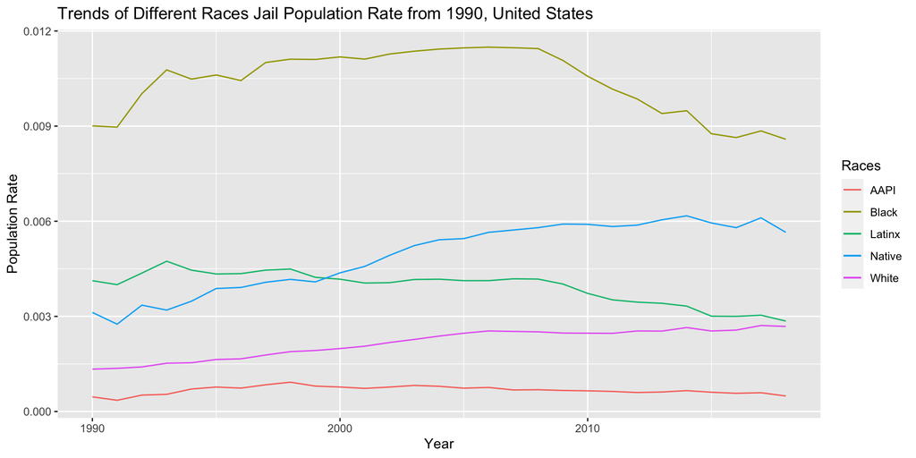

### Variable Comparison Chart

The two charts provided depict the correlation between the jail population and the prison population, each representing different racial majorities. On the left chart, the majority racial group is black, while on the right chart, the majority racial group is white. Despite the distinct definitions of jails and prisons, both graphs reveal a clear connection in the number of individuals entering these institutions.

The presented data raises important questions about the criminal justice system and calls for further examination to address any potential disparities and underlying factors contributing to the observed discrepancies between different racial groups’ experiences within the system.

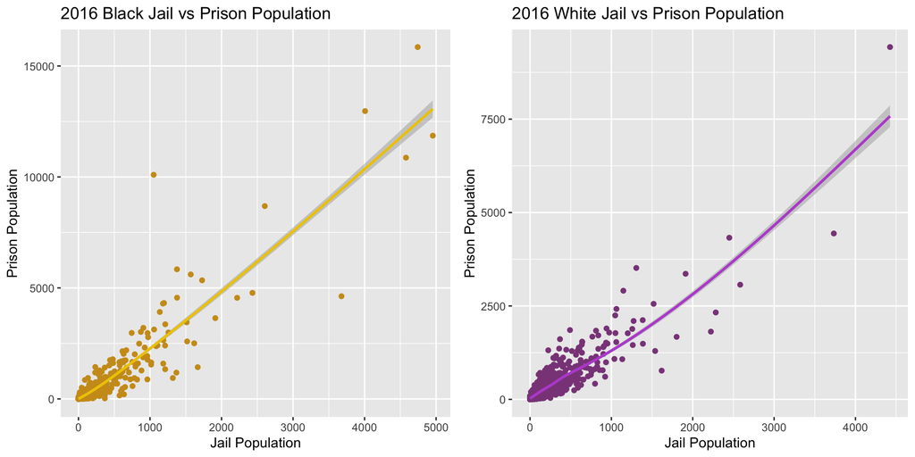

### Map

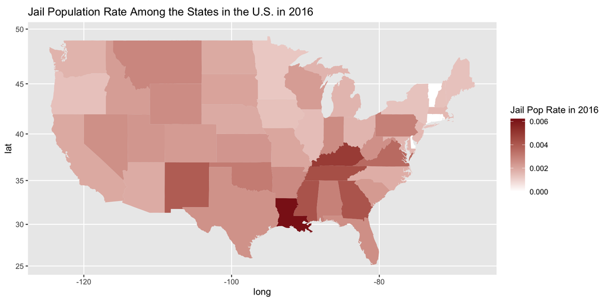